# Visualising APPLE Stock Prices

## Introduction

Trading volume is a measure of how much a given financial asset has traded in a period of time. For stocks, volume is measured in the number of shares traded. For futures and options, volume is based on how many contracts have changed hands. Traders look to volume to determine liquidity and combine changes in volume with technical indicators to make trading decisions.

```
## [1] "AAPL"
```

```
##            AAPL.Open AAPL.High AAPL.Low AAPL.Close AAPL.Volume AAPL.Adjusted
## 2007-01-03  3.081786  3.092143 2.925000   2.992857  1238319600      2.558947
## 2007-01-04  3.001786  3.069643 2.993571   3.059286   847260400      2.615745
## 2007-01-05  3.063214  3.078571 3.014286   3.037500   834741600      2.597116
## 2007-01-08  3.070000  3.090357 3.045714   3.052500   797106800      2.609943
## 2007-01-09  3.087500  3.320714 3.041071   3.306071  3349298400      2.826750
## 2007-01-10  3.383929  3.492857 3.337500   3.464286  2952880000      2.962027
```

```
##            AAPL.Open AAPL.High AAPL.Low AAPL.Close AAPL.Volume AAPL.Adjusted
## 2022-05-04    159.67    166.48   159.26     166.02   108256500      165.7764
## 2022-05-05    163.85    164.08   154.95     156.77   130525300      156.5400
## 2022-05-06    156.01    159.44   154.18     157.28   116055700      157.2800
## 2022-05-09    154.93    155.83   151.49     152.06   131577900      152.0600
## 2022-05-10    155.52    156.74   152.93     154.51   115366700      154.5100
## 2022-05-11    153.50    155.45   145.81     146.50   142341900      146.5000
```

We can see that there are 6 variables for our Dataset or commonly known as the OHLC (Open, high, low and close variables) additionally trading volume and adjusted closing price.

Let’s start visualizing the data with a basic line chart. Using the command:chartSeries(AAPL)

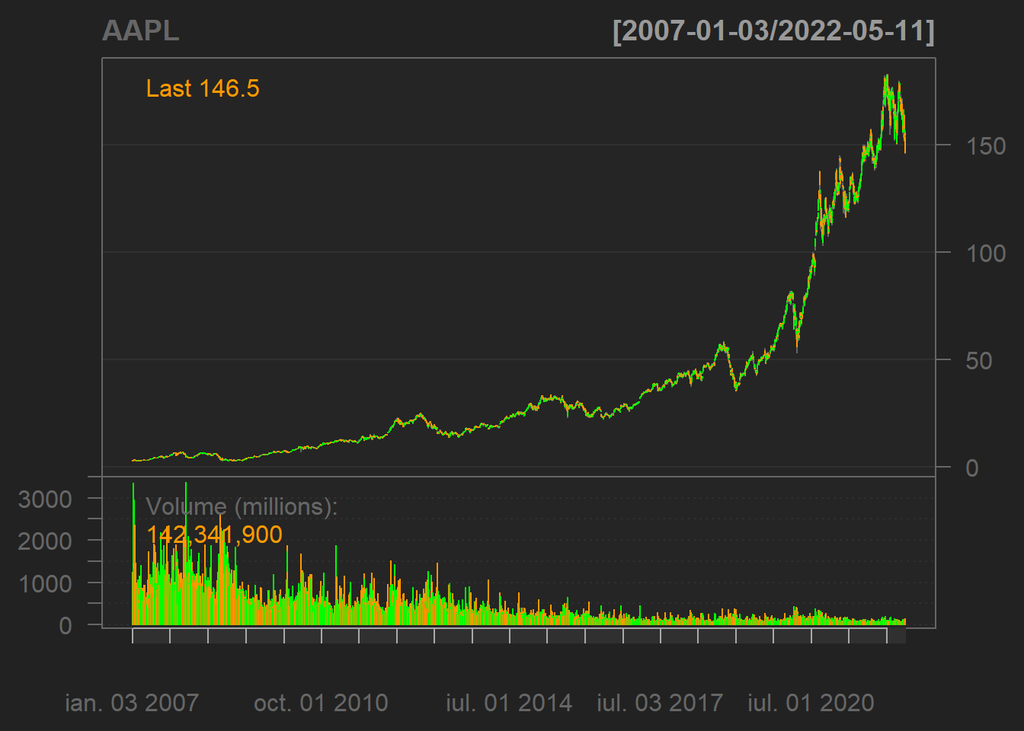

We want to perform some analysis of the AAPL stock. We obtained the highest price of the stock with the command:seriesHi(AAPL)

```
##            AAPL.Open AAPL.High AAPL.Low AAPL.Close AAPL.Volume AAPL.Adjusted
## 2022-01-04    182.63    182.94   179.12      179.7    99310400       179.208
```

We can visualize the Yearly returns of the stock with:

```
##            yearly.returns
## 2007-12-31     1.29551500
## 2008-12-31    -0.56911355
## 2009-12-31     1.46901005
## 2010-12-31     0.53067916
## 2011-12-30     0.25558038
## 2012-12-31     0.31399994
## 2013-12-31     0.05421199
## 2014-12-31     0.37724144
## 2015-12-31    -0.04638514
## 2016-12-30     0.10032297
## 2017-12-29     0.46114657
## 2018-12-31    -0.06789572
## 2019-12-31     0.86160761
## 2020-12-31     0.80745793
## 2021-12-31     0.33823200
## 2022-05-11    -0.17497328
```

Applying the line chart, we can visualize the return of the stock:

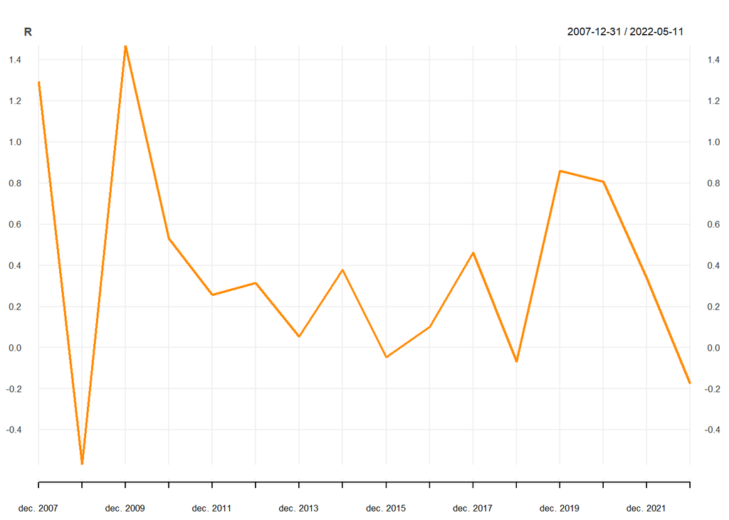

Here, we have the daily return via a histogram.

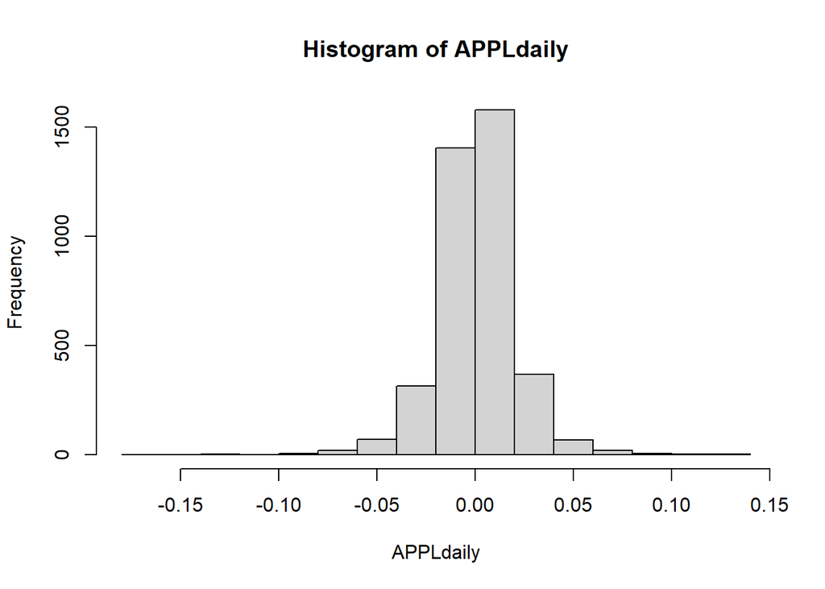